# Tugas Kuliah 2 MPDW

**Nazwa Zafira Rizaldiva (M0401241009)**

### Library

```r
library(readxl)
library(dLagM)
```

```r
library(lmtest)
library(ggplot2)
library(knitr)
library(dynlm)
library(car)
library(MLmetrics)
library(tseries)
library(forecast)
library(e1071)
```

### Data

```r
data <- read_excel("Data_Harian_2022_2024.xlsx")
head(data)
```

```
## # A tibble: 6 × 6
##   Date                  TMA    TM    PC    RH    WS
##   <dttm>              <dbl> <dbl> <dbl> <dbl> <dbl>
## 1 2022-01-01 00:00:00  595.  24.1  0.85  86.4  2.08
## 2 2022-01-02 00:00:00  588.  24.2  1.79  88.1  2.25
## 3 2022-01-03 00:00:00  580.  24.8  0.4   83.2  1.56
## 4 2022-01-04 00:00:00  576.  24.9  0.22  80.3  1.11
## 5 2022-01-05 00:00:00  574.  25.5  5.7   83.2  0.79
## 6 2022-01-06 00:00:00  584.  24.9  9.45  85.6  1.38
```

Dipilih 1 peubah bebas (X) yaitu **PC (Curah Hujan)** dan peubah terikat (Y) yaitu **TMA (Tinggi Muka Air)**.

```r
Y <- data$TMA
X <- data$PC
Date <- data$Date
```

## 1. Eksplorasi Data

### 1.1 Statistik Deskriptif

```r
summary_stat <- data.frame(
  Variabel = c("TMA (cm)", "PC (mm)"),
  Min      = c(min(Y, na.rm = TRUE), min(X, na.rm = TRUE)),
  Mean     = c(mean(Y, na.rm = TRUE), mean(X, na.rm = TRUE)),
  Median   = c(median(Y, na.rm = TRUE), median(X, na.rm = TRUE)),
  Max      = c(max(Y, na.rm = TRUE), max(X, na.rm = TRUE)),
  SD       = c(sd(Y, na.rm = TRUE), sd(X, na.rm = TRUE)),
  Skewness = c(skewness(Y, na.rm = TRUE), skewness(X, na.rm = TRUE)),
  Kurtosis = c(kurtosis(Y, na.rm = TRUE), kurtosis(X, na.rm = TRUE))
)
kable(summary_stat, digits = 3, caption = "Statistik Deskriptif Peubah TMA dan PC")
```

Statistik Deskriptif Peubah TMA dan PC

| Variabel | Min | Mean | Median | Max | SD | Skewness | Kurtosis |
| --- | --- | --- | --- | --- | --- | --- | --- |
| TMA (cm) | 555.417 | 625.345 | 620 | 781.25 | 39.450 | 0.530 | -0.021 |
| PC (mm) | 0.000 | 6.570 | 4 | 145.03 | 8.838 | 5.064 | 59.083 |

### 1.2 Visualisasi Deret Waktu

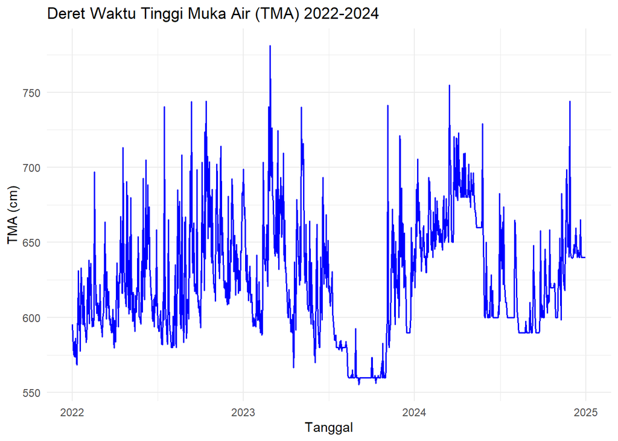

```r
# Plot deret waktu TMA
ggplot(data, aes(x = Date, y = TMA)) +
  geom_line(color = "blue", linewidth = 0.7) +
  labs(title = "Deret Waktu Tinggi Muka Air (TMA) 2022-2024",
       x = "Tanggal", y = "TMA (cm)") +
  theme_minimal()
```

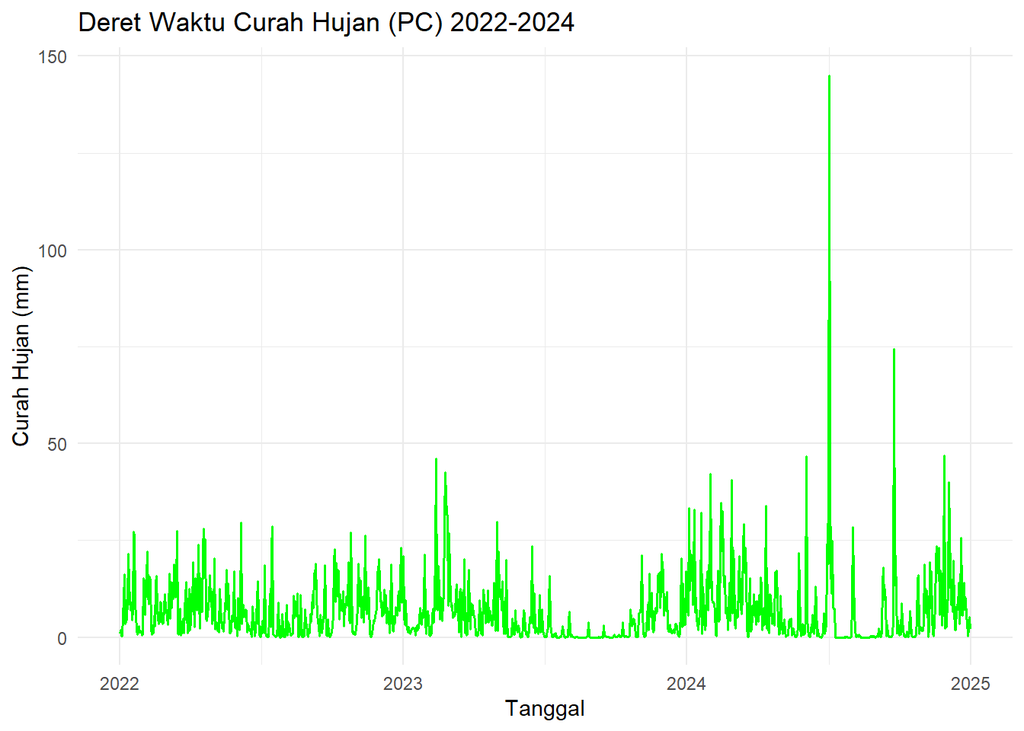

```r
# Plot deret waktu Curah Hujan (PC)
ggplot(data, aes(x = Date, y = PC)) +
  geom_line(color = "green", linewidth = 0.6) +
  labs(title = "Deret Waktu Curah Hujan (PC) 2022-2024",
       x = "Tanggal", y = "Curah Hujan (mm)") +
  theme_minimal()
```

### 1.3 Uji Stasioneritas (ADF Test)

```r
adf_tma <- adf.test(Y)
adf_pc  <- adf.test(X)
data.frame(
  Variabel  = c("TMA", "PC"),
  ADF_Stat  = c(adf_tma$statistic, adf_pc$statistic),
  p_value   = c(adf_tma$p.value, adf_pc$p.value),
  Keterangan = c(
    ifelse(adf_tma$p.value < 0.05, "Stasioner (p < 0.05)", "Tidak Stasioner"),
    ifelse(adf_pc$p.value < 0.05, "Stasioner (p < 0.05)", "Tidak Stasioner")
  )
)
```

```
##   Variabel  ADF_Stat p_value           Keterangan
## 1      TMA -4.368189    0.01 Stasioner (p < 0.05)
## 2       PC -7.553732    0.01 Stasioner (p < 0.05)
```

### 1.4 Analisis Korelasi Silang (CCF)

Fungsi korelasi silang (CCF) digunakan untuk melihat pada lag berapa curah hujan (PC) memiliki korelasi signifikan terhadap tinggi muka air (TMA):

```r
ccf_res <- ccf(X, Y, lag.max = 15, main = "Cross-Correlation: Curah Hujan (PC) vs TMA")
```

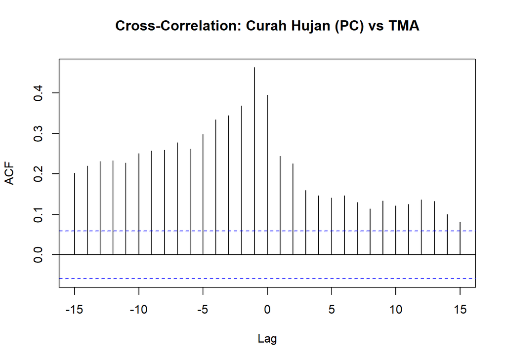

Berdasarkan plot CCF, terlihat korelasi positif yang signifikan pada lag 0 hingga beberapa lag sebelumnya, sehingga curah hujan masa kini dan masa lampau berpengaruh nyata terhadap tinggi muka air.

## 2. Pembagian Data Latih (Train) dan Uji (Test)

Sesuai proporsi data skripsi, 160 amatan terakhir digunakan sebagai data uji (test), sedangkan 936 amatan awal sebagai data latih (train):

```r
n       <- length(Y)
n_test  <- 160
n_train <- n - n_test

Y_train <- Y[1:n_train]
X_train <- X[1:n_train]

Y_test  <- Y[(n_train + 1):n]
X_test  <- X[(n_train + 1):n]
X_all   <- c(X_train, X_test)

cat("Jumlah amatan train:", n_train, "\nJumlah amatan test :", n_test, "\n")
```

```
## Jumlah amatan train: 936
## Jumlah amatan test : 160
```

### 2.1 Fungsi Evaluasi

Fungsi MAPE (Mean Absolute Percentage Error) didefinisikan sebagai berikut:

```r
mape <- function(actual, pred) {
  mean(abs((actual - pred) / actual), na.rm = TRUE) * 100
}
```

## 3. Model Koyck (ARL)

Model Koyck mengasumsikan bahwa koefisien lag dari peubah bebas X menurun secara eksponensial seiring bertambahnya lag.

```r
koyck <- koyckDlm(x = X_train, y = Y_train)
summary(koyck$model)
```

```
##
## Call:
## "Y ~ (Intercept) + Y.1 + X.t"
##
## Residuals:
##      Min       1Q   Median       3Q      Max
## -243.226  -11.740   -1.728   10.885  133.699
##
## Coefficients:
##             Estimate Std. Error t value Pr(>|t|)
## (Intercept) 184.5716    14.3704  12.844  < 2e-16 ***
## Y.1           0.6826     0.0243  28.096  < 2e-16 ***
## X.t           2.1376     0.2590   8.254 5.22e-16 ***
## ---
## Signif. codes:  0 '***' 0.001 '**' 0.01 '*' 0.05 '.' 0.1 ' ' 1
##
## Residual standard error: 25.54 on 932 degrees of freedom
## Multiple R-Squared: 0.6147,  Adjusted R-squared: 0.6139
## Wald test: 793.8 on 2 and 932 DF,  p-value: < 2.2e-16
```

### 3.1 Parameter dan Lag Optimum Koyck

```r
b_k <- coef(koyck$model)
lambda <- b_k[2]
beta0  <- b_k[3]

# Mean lag dan Median lag
mean_lag_koyck   <- lambda / (1 - lambda)
median_lag_koyck <- -log(2) / log(lambda)

data.frame(
  Parameter = c("Lambda (Koefisien Y_t-1)", "Beta 0 (Koefisien X_t)", "Mean Lag", "Median Lag"),
  Nilai     = round(c(lambda, beta0, mean_lag_koyck, median_lag_koyck), 4)
)
```

```
##                  Parameter  Nilai
## 1 Lambda (Koefisien Y_t-1) 0.6826
## 2   Beta 0 (Koefisien X_t) 2.1376
## 3                 Mean Lag 2.1509
## 4               Median Lag 1.8154
```

### 3.2 Uji Diagnostik Sisaan Koyck

```r
bg_koyck <- bgtest(koyck$model)
bp_koyck <- bptest(koyck$model)
sw_koyck <- shapiro.test(residuals(koyck$model))

data.frame(
  Uji_Asumsi = c("Autokorelasi (Breusch-Godfrey)", "Heteroskedastisitas (Breusch-Pagan)", "Normalitas (Shapiro-Wilk)"),
  Statistik  = c(bg_koyck$statistic, bp_koyck$statistic, sw_koyck$statistic),
  p_value    = c(bg_koyck$p.value, bp_koyck$p.value, sw_koyck$p.value)
)
```

```
##                                  Uji_Asumsi  Statistik      p_value
## LM test      Autokorelasi (Breusch-Godfrey) 94.3213016 2.682480e-22
## BP      Heteroskedastisitas (Breusch-Pagan) 61.8820221 3.651654e-14
## W                 Normalitas (Shapiro-Wilk)  0.9075501 2.309746e-23
```

### 3.3 Peramalan Data Uji Koyck

```r
pred_koyck <- numeric(n_test)
y_prev <- tail(Y_train, 1)

for (i in 1:n_test) {
  pred_koyck[i] <- b_k[1] + b_k[2] * y_prev + b_k[3] * X_test[i]
  y_prev <- pred_koyck[i]
}

mape_koyck <- mape(Y_test, pred_koyck)
n_koyck   <- length(residuals(koyck$model))
k_koyck   <- length(coef(koyck$model))
rss_koyck <- sum(residuals(koyck$model)^2)
aic_koyck <- n_koyck * log(rss_koyck / n_koyck) + 2 * (k_koyck + 1)
dev_koyck <- rss_koyck

cat("Koyck - MAPE Test:", round(mape_koyck, 3), "%\n")
```

```
## Koyck - MAPE Test: 2.997 %
```

```r
cat("Koyck - AIC      :", round(aic_koyck, 2), "\n")
```

```
## Koyck - AIC      : 6064.34
```

```r
cat("Koyck - Deviance :", round(dev_koyck, 2), "\n")
```

```
## Koyck - Deviance : 607988.9
```

## 4. Model Distributed Lag Model (DLM)

Model DLM berhingga mengasumsikan bahwa peubah terikat Yt dipengaruhi oleh nilai peubah penjelas X pada saat ini hingga q periode sebelumnya

### 4.1 Penentuan Lag q Optimum

Lag q optimum dipilih berdasarkan nilai AIC terkecil dari kandidat lag q=1 hingga q=8 :

```r
q_try <- 1:8
aic_q <- sapply(q_try, function(q) AIC(dlm(x = X_train, y = Y_train, q = q)$model))

tabel_aic_q <- data.frame(Lag_q = q_try, AIC = aic_q)
kable(tabel_aic_q, digits = 2, caption = "Pemilihan Lag q Optimum Model DLM")
```

Pemilihan Lag q Optimum Model DLM

| Lag_q | AIC |
| --- | --- |
| 1 | 9329.36 |
| 2 | 9294.82 |
| 3 | 9261.37 |
| 4 | 9226.71 |
| 5 | 9196.32 |
| 6 | 9174.37 |
| 7 | 9141.24 |
| 8 | 9115.32 |

```r
q_opt <- q_try[which.min(aic_q)]
cat("Lag q optimum terpilih:", q_opt, "\n")
```

```
## Lag q optimum terpilih: 8
```

### 4.2 Estimasi Model DLM Optimum

```r
dlm_model <- dlm(x = X_train, y = Y_train, q = q_opt)
summary(dlm_model$model)
```

```
##
## Call:
## lm(formula = model.formula, data = design)
##
## Residuals:
##      Min       1Q   Median       3Q      Max
## -190.609  -22.449   -4.759   15.569  105.289
##
## Coefficients:
##             Estimate Std. Error t value Pr(>|t|)
## (Intercept) 594.2547     1.7909 331.810  < 2e-16 ***
## x.t           0.8889     0.1394   6.376 2.87e-10 ***
## x.1           1.2541     0.1477   8.489  < 2e-16 ***
## x.2           0.3550     0.1484   2.392  0.01695 *
## x.3           0.3537     0.1492   2.370  0.01799 *
## x.4           0.3621     0.1491   2.428  0.01535 *
## x.5           0.3460     0.1492   2.319  0.02059 *
## x.6           0.2261     0.1484   1.524  0.12793
## x.7           0.4778     0.1476   3.238  0.00125 **
## x.8           0.5846     0.1393   4.198 2.96e-05 ***
## ---
## Signif. codes:  0 '***' 0.001 '**' 0.01 '*' 0.05 '.' 0.1 ' ' 1
##
## Residual standard error: 32.65 on 918 degrees of freedom
## Multiple R-squared:  0.3739, Adjusted R-squared:  0.3677
## F-statistic:  60.9 on 9 and 918 DF,  p-value: < 2.2e-16
```

### 4.3 Uji Diagnostik Sisaan DLM

```r
bg_dlm <- bgtest(dlm_model$model)
bp_dlm <- bptest(dlm_model$model)
sw_dlm <- shapiro.test(residuals(dlm_model$model))

data.frame(
  Uji_Asumsi = c("Autokorelasi (Breusch-Godfrey)", "Heteroskedastisitas (Breusch-Pagan)", "Normalitas (Shapiro-Wilk)"),
  Statistik  = c(bg_dlm$statistic, bp_dlm$statistic, sw_dlm$statistic),
  p_value    = c(bg_dlm$p.value, bp_dlm$p.value, sw_dlm$p.value)
)
```

```
##                                  Uji_Asumsi   Statistik       p_value
## LM test      Autokorelasi (Breusch-Godfrey) 451.3265540 3.710408e-100
## BP      Heteroskedastisitas (Breusch-Pagan) 190.1697172  3.793382e-36
## W                 Normalitas (Shapiro-Wilk)   0.9578192  1.075370e-15
```

### 4.4 Peramalan Data Uji (DLM)

```r
b_dlm <- coef(dlm_model$model)

pred_dlm <- sapply((n_train + 1):n, function(t) {
  sum(b_dlm * c(1, X_all[t - 0:q_opt]))
})

mape_dlm <- mape(Y_test, pred_dlm)
dev_dlm  <- deviance(dlm_model$model)
aic_dlm  <- AIC(dlm_model$model)

cat("DLM - MAPE Test:", round(mape_dlm, 3), "%\n")
```

```
## DLM - MAPE Test: 2.504 %
```

```r
cat("DLM - AIC      :", round(aic_dlm, 2), "\n")
```

```
## DLM - AIC      : 9115.32
```

```r
cat("DLM - Deviance :", round(dev_dlm, 2), "\n")
```

```
## DLM - Deviance : 978706.3
```

## 5. Model Autoregressive Distributed Lag (ARDL)

Model ARDL menggabungkan struktur autoregresif dari peubah Y dengan lag berhingga dari peubah penjelas X

### 5.1 Penentuan Ordo (p,q) Optimum

Kombinasi ordo (p,q) dicari menggunakan grid search dengan kriteria AIC minimum:

```r
grid <- expand.grid(p = 1:4, q = 1:4)
grid$AIC <- mapply(function(p, q) AIC(ardlDlm(x = X_train, y = Y_train, p = p, q = q)$model),
                   grid$p, grid$q)

grid_sorted <- grid[order(grid$AIC), ]
head(grid_sorted, 5)
```

```
##    p q      AIC
## 14 2 4 8378.114
## 15 3 4 8378.550
## 16 4 4 8380.205
## 12 4 3 8392.649
## 13 1 4 8394.267
```

```r
p_opt  <- grid$p[which.min(grid$AIC)]
q_opt2 <- grid$q[which.min(grid$AIC)]
cat("Ordo ARDL optimum terpilih: p (lag X) =", p_opt, ", q (lag Y) =", q_opt2, "\n")
```

```
## Ordo ARDL optimum terpilih: p (lag X) = 2 , q (lag Y) = 4
```

### 5.2 Estimasi MOdel ARDL Optimum

```r
ardl_model <- ardlDlm(x = X_train, y = Y_train, p = p_opt, q = q_opt2)
summary(ardl_model$model)
```

```
##
## Time series regression with "ts" data:
## Start = 5, End = 936
##
## Call:
## dynlm(formula = as.formula(model.text), data = data, start = 1)
##
## Residuals:
##      Min       1Q   Median       3Q      Max
## -130.822  -11.142   -3.508    6.451  131.839
##
## Coefficients:
##              Estimate Std. Error t value Pr(>|t|)
## (Intercept) 103.42820   12.93784   7.994 3.88e-15 ***
## X.t           0.76046    0.09209   8.258 5.09e-16 ***
## X.1           0.84379    0.10090   8.362 2.25e-16 ***
## X.2          -0.42462    0.09960  -4.263 2.22e-05 ***
## Y.1           0.44031    0.03233  13.620  < 2e-16 ***
## Y.2           0.17236    0.03420   5.039 5.63e-07 ***
## Y.3           0.08908    0.03389   2.628  0.00872 **
## Y.4           0.12066    0.02985   4.042 5.73e-05 ***
## ---
## Signif. codes:  0 '***' 0.001 '**' 0.01 '*' 0.05 '.' 0.1 ' ' 1
##
## Residual standard error: 21.55 on 924 degrees of freedom
## Multiple R-squared:  0.727,  Adjusted R-squared:  0.7249
## F-statistic: 351.5 on 7 and 924 DF,  p-value: < 2.2e-16
```

### 5.3 Uji Diagnostik Sisaan ARDL

```r
bg_ardl <- bgtest(ardl_model$model)
bp_ardl <- bptest(ardl_model$model)
sw_ardl <- shapiro.test(residuals(ardl_model$model))

data.frame(
  Uji_Asumsi = c("Autokorelasi (Breusch-Godfrey)", "Heteroskedastisitas (Breusch-Pagan)", "Normalitas (Shapiro-Wilk)"),
  Statistik  = c(bg_ardl$statistic, bp_ardl$statistic, sw_ardl$statistic),
  p_value    = c(bg_ardl$p.value, bp_ardl$p.value, sw_ardl$p.value)
)
```

```
##                                  Uji_Asumsi   Statistik      p_value
## LM test      Autokorelasi (Breusch-Godfrey)   3.6946145 5.458840e-02
## BP      Heteroskedastisitas (Breusch-Pagan) 192.0817185 5.443546e-38
## W                 Normalitas (Shapiro-Wilk)   0.8873952 1.732949e-25
```

### 5.4 Peramalan Data Uji ARDL

```r
b_ardl <- coef(ardl_model$model)
Y_all  <- c(Y_train, rep(NA, n_test))

for (t in (n_train + 1):n) {
  x_terms <- X_all[t - 0:p_opt]
  y_terms <- Y_all[t - 1:q_opt2]
  Y_all[t] <- sum(b_ardl * c(1, x_terms, y_terms))
}

pred_ardl <- Y_all[(n_train + 1):n]

mape_ardl <- mape(Y_test, pred_ardl)
dev_ardl  <- deviance(ardl_model$model)
aic_ardl  <- AIC(ardl_model$model)

cat("ARDL - MAPE Test:", round(mape_ardl, 3), "%\n")
```

```
## ARDL - MAPE Test: 2.334 %
```

```r
cat("ARDL - AIC      :", round(aic_ardl, 2), "\n")
```

```
## ARDL - AIC      : 8378.11
```

```r
cat("ARDL - Deviance :", round(dev_ardl, 2), "\n")
```

```
## ARDL - Deviance : 429138.4
```

## 6. Perbandingan Model

Berikut adalah tabel perbandingan performa ketiga model pada kriteria AIC, Deviance, dan akurasi peramalan data uji (MAPE):

```r
hasil <- data.frame(
  Model    = c("Koyck (ARL)", "DLM", "ARDL"),
  Ordo_Lag = c(paste0("lambda = ", round(lambda, 3)),
               paste0("q = ", q_opt),
               paste0("p = ", p_opt, ", q = ", q_opt2)),
  AIC      = round(c(aic_koyck, aic_dlm, aic_ardl), 2),
  Deviance = round(c(dev_koyck, dev_dlm, dev_ardl), 2),
  MAPE_Test= round(c(mape_koyck, mape_dlm, mape_ardl), 3)
)

kable(hasil, caption = "Tabel Perbandingan Kebaikan Model dan Akurasi Peramalan")
```

Tabel Perbandingan Kebaikan Model dan Akurasi Peramalan

| Model | Ordo_Lag | AIC | Deviance | MAPE_Test |
| --- | --- | --- | --- | --- |
| Koyck (ARL) | lambda = 0.683 | 6064.34 | 607988.9 | 2.997 |
| DLM | q = 8 | 9115.32 | 978706.3 | 2.504 |
| ARDL | p = 2, q = 4 | 8378.11 | 429138.4 | 2.334 |

### 6.1 Visualisasi Perbandingan MAPE

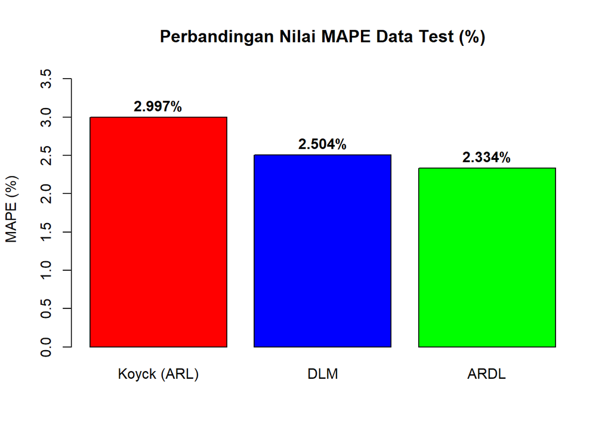

```r
barplot(
  hasil$MAPE_Test,
  names.arg = hasil$Model,
  col = c("red", "blue", "green"),
  main = "Perbandingan Nilai MAPE Data Test (%)",
  ylab = "MAPE (%)",
  ylim = c(0, max(hasil$MAPE_Test) * 1.2)
)
text(
  x = c(0.7, 1.9, 3.1),
  y = hasil$MAPE_Test + 0.15,
  labels = paste0(hasil$MAPE_Test, "%"),
  font = 2
)
```

### 6.2 Visualisasi Data Aktual vs Hasil Prediksi

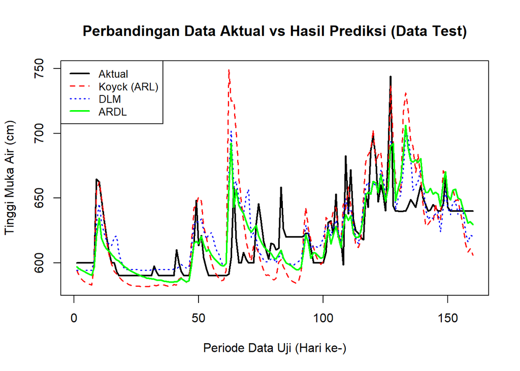

```r
plot(
  Y_test,
  type = "l",
  col = "black",
  lwd = 2,
  ylim = range(c(Y_test, pred_koyck, pred_dlm, pred_ardl)),
  ylab = "Tinggi Muka Air (cm)",
  xlab = "Periode Data Uji (Hari ke-)",
  main = "Perbandingan Data Aktual vs Hasil Prediksi (Data Test)"
)
lines(pred_koyck, col = "red", lty = 2, lwd = 1.5)
lines(pred_dlm,   col = "blue", lty = 3, lwd = 1.5)
lines(pred_ardl,  col = "green", lty = 1, lwd = 2)

legend(
  "topleft",
  legend = c("Aktual", "Koyck (ARL)", "DLM", "ARDL"),
  col = c("black", "red", "blue", "green"),
  lty = c(1, 2, 3, 1),
  lwd = c(2, 1.5, 1.5, 2),
  cex = 0.85
)
```

## 7. Kesimpulan

```r
best_model <- hasil$Model[which.min(hasil$MAPE_Test)]
best_mape  <- min(hasil$MAPE_Test)

best_model
```

```
## [1] "ARDL"
```

```r
best_mape
```

```
## [1] 2.334
```